# Table of Contents

# Objective

1- Profile and describe the data-set and its attributes to your best ability. List any anomalies and patterns. (Please share any Python code/Graphs used)

2- Create the accuracy rate/measure of the current forecasted results (Please share any Python code/Graphs used)

3- Create an algorithm using Python based on the existing data-set and compare the accuracy of the forecasted sales & actual sales (Please share the Python Code).

4- Explain the accuracy of your predicted model and the evaluation steps involved. (Please share the Python Code).

5- List the next steps on how you can improve the accuracy of your model

## Solution Summary

Two approaches are suggested. The first approach is to use the given features only as independent variables and to predict the (Actual Sale). The second approach is using lagging, i.e., the (Actual Sale) of the previous day as an independ feature as well. The second approach gave better accuracy.

Different mechanisims could be used to improve the accuracy, such as trying more on feature engineering, tunning the parameters of the model or using stacking models.

```python
#Basic libraries
import pandas as pd
import numpy as np
import datetime

#Graphic libraries
import matplotlib.pyplot as plt
%matplotlib inline

import seaborn as sns
#Quick EDA
import pandas_profiling

import warnings
warnings.filterwarnings('ignore')
pd.set_option('display.max_columns', 500)

%config InlineBackend.figure_format = 'retina'
%load_ext autoreload
%autoreload 2
```

```
The autoreload extension is already loaded. To reload it, use:
  %reload_ext autoreload
```

```python
#############################################
#         evaluation function               #
#############################################
#Evaluation metrics
from sklearn.metrics import (
                             r2_score,
                             mean_squared_error,
                             mean_absolute_error,
                             make_scorer)
# MAPE
def mean_absolute_percentage_error(y_true, y_pred):
    return np.mean(np.abs((y_true - y_pred) / y_true)) * 100

#SMAPE
def symmetric_mean_absolute_percentage_error(y_true, y_pred):
    return np.mean(np.abs(2 * (y_true - y_pred) / (y_true + y_pred))) * 100

# PE
def percentage_error(y_true, y_pred):
    return ((y_true - y_pred) / y_true) * 100

# Error
def error(y_true, y_pred):
    return np.abs(y_true - y_pred)

# RMSE
def root_mean_square_error(y_true, y_pred):
    return np.sqrt(mean_squared_error(y_true, y_pred))

# RMSPE
def root_mean_square_percent_error(y_true, y_pred):
    return np.sqrt(np.mean(np.square(((y_true - y_pred) / y_true)), axis=0))

from sklearn.metrics import r2_score
```

## Load Data

```python
data_df = pd.read_excel('./data/PredictiveTestSet.xlsx', parse_dates=["SaleDate"], index_col='RecordID')
```

## Data Profile

Overview

Dataset info

| Number of variables | 9 |
| --- | --- |
| Number of observations | 494095 |
| Total Missing (%) | 11.1% |
| Total size in memory | 33.9 MiB |
| Average record size in memory | 72.0 B |

Variables types

| Numeric | 2 |
| --- | --- |
| Categorical | 4 |
| Boolean | 0 |
| Date | 1 |
| Text (Unique) | 0 |
| Rejected | 2 |
| Unsupported | 0 |

Warnings

- `Acutal Sales` is highly correlated with `Predicted Sales` (ρ = 0.91138) Rejected

- `Predicted Sales` has 16038 / 3.2% zeros Zeros

- `Predicted Sales Test (Using X Algorithm)` has 494095 / 100.0% missing values Missing

- `Predicted Sales Test (Using X Algorithm)` has constant value Rejected

- `Product` has a high cardinality: 103 distinct values Warning

- `Store` has a high cardinality: 1758 distinct values Warning

Variables

Acutal Sales  
Highly correlated

*This variable is highly correlated with `Predicted Sales` and should be ignored for analysis*

| Correlation | 0.91138 |
| --- | --- |

Predicted Sales  
Numeric

| Distinct count | 286 |
| --- | --- |
| Unique (%) | 0.1% |
| Missing (%) | 0.0% |
| Missing (n) | 2 |
| Infinite (%) | 0.0% |
| Infinite (n) | 0 |

| Mean | 7.6626 |
| --- | --- |
| Minimum | 0 |
| Maximum | 1020 |
| Zeros (%) | 3.2% |

Toggle details

**Statistics**

Quantile statistics

| Minimum | 0 |
| --- | --- |
| 5-th percentile | 1 |
| Q1 | 2 |
| Median | 4 |
| Q3 | 8 |
| 95-th percentile | 26 |
| Maximum | 1020 |
| Range | 1020 |
| Interquartile range | 6 |

Descriptive statistics

| Standard deviation | 13.766 |
| --- | --- |
| Coef of variation | 1.7965 |
| Kurtosis | 224.11 |
| Mean | 7.6626 |
| MAD | 6.7873 |
| Skewness | 9.8297 |
| Sum | 3786000 |
| Variance | 189.5 |
| Memory size | 3.8 MiB |

**Histogram**

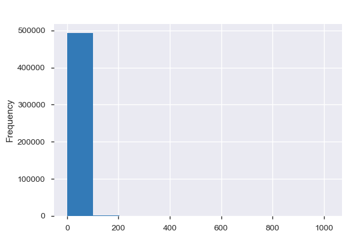

**Common Values**

| Value | Count | Frequency (%) |  |
| --- | --- | --- | --- |
| 2.0 | 89537 | 18.1% |  |
| 1.0 | 70472 | 14.3% |  |
| 3.0 | 58063 | 11.8% |  |
| 4.0 | 45417 | 9.2% |  |
| 5.0 | 31012 | 6.3% |  |
| 6.0 | 27574 | 5.6% |  |
| 8.0 | 18846 | 3.8% |  |
| 7.0 | 17880 | 3.6% |  |
| 0.0 | 16038 | 3.2% |  |
| 10.0 | 14583 | 3.0% |  |
| Other values (275) | 104671 | 21.2% |  |

**Extreme Values**

Minimum 5 values

| Value | Count | Frequency (%) |  |
| --- | --- | --- | --- |
| 0.0 | 16038 | 3.2% |  |
| 1.0 | 70472 | 14.3% |  |
| 2.0 | 89537 | 18.1% |  |
| 3.0 | 58063 | 11.8% |  |
| 4.0 | 45417 | 9.2% |  |

Maximum 5 values

| Value | Count | Frequency (%) |  |
| --- | --- | --- | --- |
| 527.0 | 1 | 0.0% |  |
| 530.0 | 2 | 0.0% |  |
| 550.0 | 1 | 0.0% |  |
| 557.0 | 2 | 0.0% |  |
| 1020.0 | 1 | 0.0% |  |

Predicted Sales Test (Using X Algorithm)  
Constant

*This variable is constant and should be ignored for analysis*

| Constant value |  |
| --- | --- |

Product  
Categorical

| Distinct count | 103 |
| --- | --- |
| Unique (%) | 0.0% |
| Missing (%) | 0.0% |
| Missing (n) | 0 |

| ax34 | 10353 |
| --- | --- |
| ax10 | 10324 |
| ax8 | 10286 |
| Other values (100) | 463132 |

Toggle details

| Value | Count | Frequency (%) |  |
| --- | --- | --- | --- |
| ax34 | 10353 | 2.1% |  |
| ax10 | 10324 | 2.1% |  |
| ax8 | 10286 | 2.1% |  |
| ax11 | 10263 | 2.1% |  |
| ax72 | 10244 | 2.1% |  |
| ax12 | 10083 | 2.0% |  |
| ax7 | 10029 | 2.0% |  |
| ax73 | 9871 | 2.0% |  |
| ax51 | 9807 | 2.0% |  |
| ax59 | 9747 | 2.0% |  |
| Other values (93) | 393088 | 79.6% |  |

ProductFamily  
Categorical

| Distinct count | 6 |
| --- | --- |
| Unique (%) | 0.0% |
| Missing (%) | 0.0% |
| Missing (n) | 0 |

| ClassE | 286265 |
| --- | --- |
| ClassA | 115408 |
| ClassF | 49822 |
| Other values (3) | 42600 |

Toggle details

| Value | Count | Frequency (%) |  |
| --- | --- | --- | --- |
| ClassE | 286265 | 57.9% |  |
| ClassA | 115408 | 23.4% |  |
| ClassF | 49822 | 10.1% |  |
| ClassB | 20112 | 4.1% |  |
| ClassD | 14362 | 2.9% |  |
| ClassC | 8126 | 1.6% |  |

RecordID  
Numeric

| Distinct count | 494095 |
| --- | --- |
| Unique (%) | 100.0% |
| Missing (%) | 0.0% |
| Missing (n) | 0 |
| Infinite (%) | 0.0% |
| Infinite (n) | 0 |

| Mean | 247050 |
| --- | --- |
| Minimum | 1 |
| Maximum | 494095 |
| Zeros (%) | 0.0% |

Toggle details

**Statistics**

Quantile statistics

| Minimum | 1 |
| --- | --- |
| 5-th percentile | 24706 |
| Q1 | 123520 |
| Median | 247050 |
| Q3 | 370570 |
| 95-th percentile | 469390 |
| Maximum | 494095 |
| Range | 494094 |
| Interquartile range | 247050 |

Descriptive statistics

| Standard deviation | 142630 |
| --- | --- |
| Coef of variation | 0.57735 |
| Kurtosis | -1.2 |
| Mean | 247050 |
| MAD | 123520 |
| Skewness | 1.2113e-15 |
| Sum | 122065181560 |
| Variance | 20344000000 |
| Memory size | 3.8 MiB |

**Histogram**

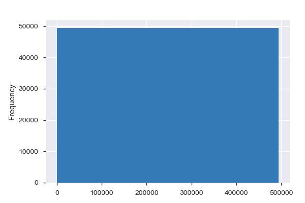

**Common Values**

| Value | Count | Frequency (%) |  |
| --- | --- | --- | --- |
| 2047 | 1 | 0.0% |  |
| 81037 | 1 | 0.0% |  |
| 15533 | 1 | 0.0% |  |
| 9390 | 1 | 0.0% |  |
| 11439 | 1 | 0.0% |  |
| 54448 | 1 | 0.0% |  |
| 56497 | 1 | 0.0% |  |
| 50354 | 1 | 0.0% |  |
| 52403 | 1 | 0.0% |  |
| 62644 | 1 | 0.0% |  |
| Other values (494085) | 494085 | 100.0% |  |

**Extreme Values**

Minimum 5 values

| Value | Count | Frequency (%) |  |
| --- | --- | --- | --- |
| 1 | 1 | 0.0% |  |
| 2 | 1 | 0.0% |  |
| 3 | 1 | 0.0% |  |
| 4 | 1 | 0.0% |  |
| 5 | 1 | 0.0% |  |

Maximum 5 values

| Value | Count | Frequency (%) |  |
| --- | --- | --- | --- |
| 494091 | 1 | 0.0% |  |
| 494092 | 1 | 0.0% |  |
| 494093 | 1 | 0.0% |  |
| 494094 | 1 | 0.0% |  |
| 494095 | 1 | 0.0% |  |

SaleDate  
Date

| Distinct count | 7 |
| --- | --- |
| Unique (%) | 0.0% |
| Missing (%) | 0.0% |
| Missing (n) | 0 |
| Infinite (%) | 0.0% |
| Infinite (n) | 0 |

| Minimum | 2018-10-29 00:00:00 |
| --- | --- |
| Maximum | 2018-11-04 00:00:00 |

Toggle details

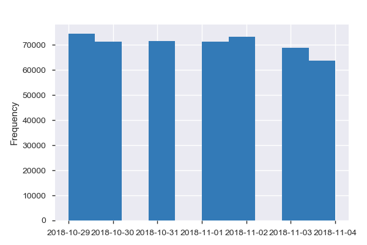

Store  
Categorical

| Distinct count | 1758 |
| --- | --- |
| Unique (%) | 0.4% |
| Missing (%) | 0.0% |
| Missing (n) | 0 |

| st993 | 430 |
| --- | --- |
| st1046 | 425 |
| st1122 | 424 |
| Other values (1755) | 492816 |

Toggle details

| Value | Count | Frequency (%) |  |
| --- | --- | --- | --- |
| st993 | 430 | 0.1% |  |
| st1046 | 425 | 0.1% |  |
| st1122 | 424 | 0.1% |  |
| st1142 | 423 | 0.1% |  |
| st860 | 422 | 0.1% |  |
| st1537 | 420 | 0.1% |  |
| st1227 | 419 | 0.1% |  |
| st1621 | 417 | 0.1% |  |
| st878 | 417 | 0.1% |  |
| st798 | 414 | 0.1% |  |
| Other values (1748) | 489884 | 99.1% |  |

sales_district_text  
Categorical

| Distinct count | 5 |
| --- | --- |
| Unique (%) | 0.0% |
| Missing (%) | 0.0% |
| Missing (n) | 0 |

| New South Wales | 147437 |
| --- | --- |
| Victoria | 136566 |
| Queensland | 117743 |
| Other values (2) | 92349 |

Toggle details

| Value | Count | Frequency (%) |  |
| --- | --- | --- | --- |
| New South Wales | 147437 | 29.8% |  |
| Victoria | 136566 | 27.6% |  |
| Queensland | 117743 | 23.8% |  |
| Western Australia | 53872 | 10.9% |  |
| South Australia | 38477 | 7.8% |  |

Correlations

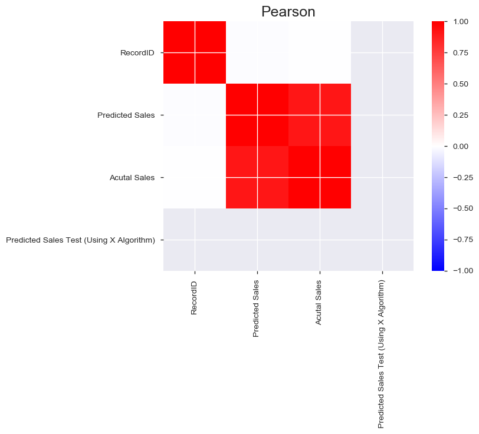

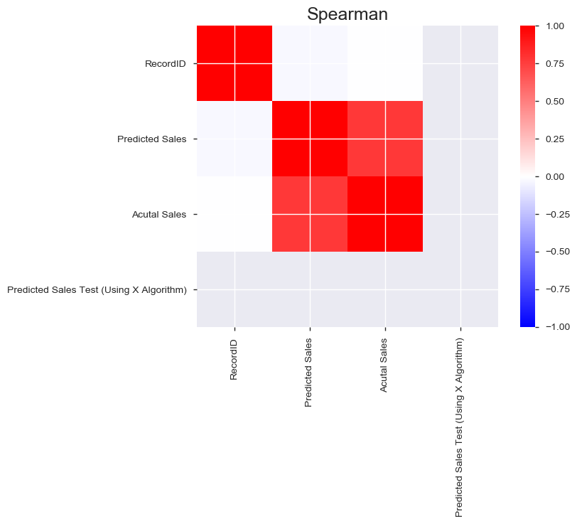

Sample

|  | RecordID | SaleDate | sales_district_text | Predicted Sales | Acutal Sales | Store | Product | ProductFamily | Predicted Sales Test (Using X Algorithm) |
| --- | --- | --- | --- | --- | --- | --- | --- | --- | --- |
| 0 | 1 | 2018-10-29 | New South Wales | 12.0 | 11 | st11 | ax33 | ClassA | NaN |
| 1 | 2 | 2018-10-29 | New South Wales | 36.0 | 16 | st11 | ax34 | ClassA | NaN |
| 2 | 3 | 2018-10-29 | New South Wales | 5.0 | 2 | st11 | ax35 | ClassA | NaN |
| 3 | 4 | 2018-10-29 | New South Wales | 8.0 | 2 | st11 | ax36 | ClassA | NaN |
| 4 | 5 | 2018-10-29 | New South Wales | 8.0 | 7 | st11 | ax37 | ClassA | NaN |

```python
pandas_profiling.ProfileReport(data_df.reset_index(), check_correlation=True)
```

## Feature engineering and data cleaning

```python
#Removing missing values in the 'Predicted Sales'
data_df.dropna(inplace=True, subset=['Predicted Sales'])

#Removing negative values in 'Actual Sale'
data_df = data_df[data_df['Acutal Sales'] >= 0.0]
```

```python
#Extract day of week and month
data_df['dayofweek'] = data_df.SaleDate.dt.dayofweek
data_df['weekday_name'] = data_df.SaleDate.dt.weekday_name
data_df['month'] = data_df.SaleDate.dt.month
```

```python
categorial_features = ['weekday_name', 'sales_district_text', 'Store', 'Product', 'ProductFamily']
```

## EDA

### Sale per ProductFamily

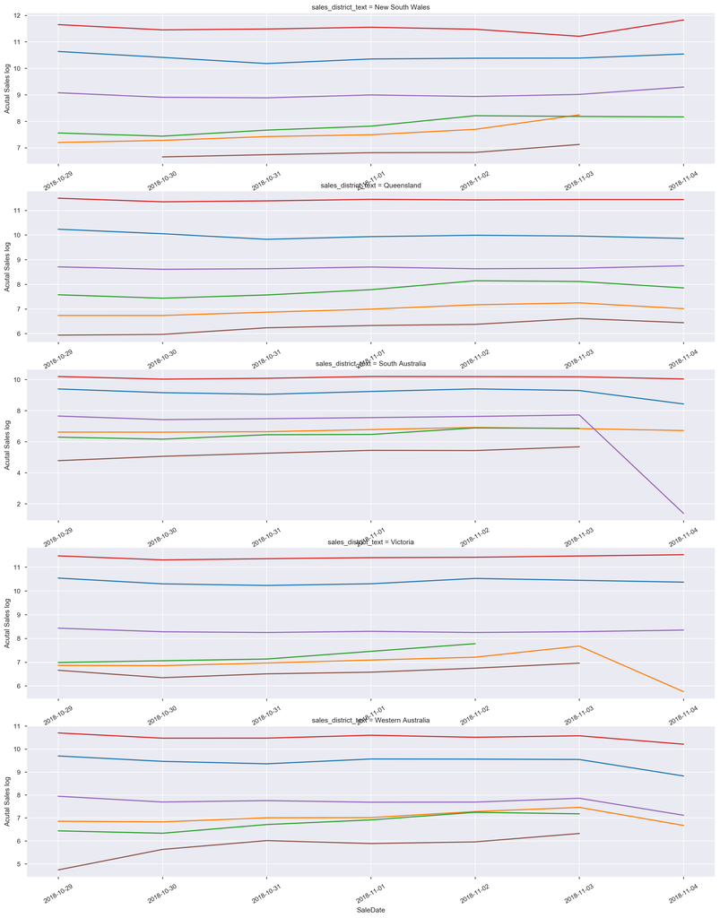

```python
_ = data_df.groupby(['SaleDate', 'sales_district_text', 'ProductFamily'])['Acutal Sales'].sum().reset_index()
_['Acutal Sales log'] = np.log(_['Acutal Sales'])
g = sns.FacetGrid(data=_, row = "sales_district_text", hue='ProductFamily',
                  sharey=False, sharex=False, height=4, aspect=4)
g.map(plt.plot, 'SaleDate', 'Acutal Sales log')
g.set_xticklabels(rotation=30)
plt.show()
```

## Sale by product

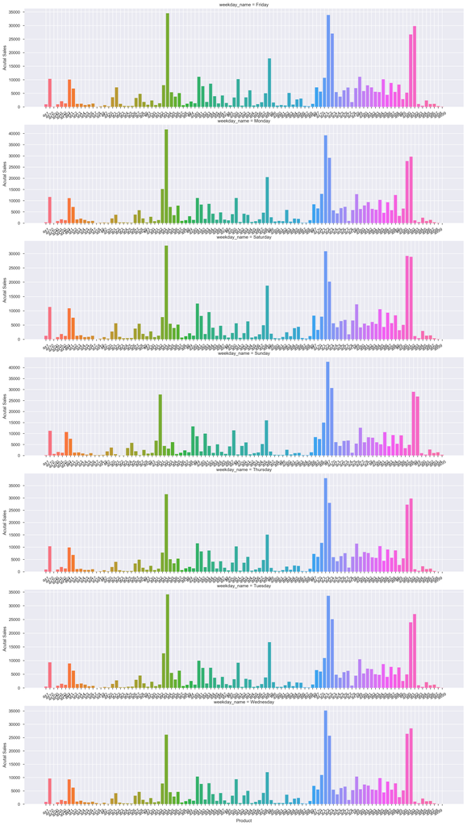

```python
_ = data_df.groupby(['weekday_name', 'Product'])['Acutal Sales'].sum().reset_index()
_['Acutal Sales log'] = np.log(_['Acutal Sales'])
g = sns.FacetGrid(data=_, row = "weekday_name", hue='Product',
                  sharey=False, sharex=False, height=4, aspect=4)
g.map(plt.bar, 'Product', 'Acutal Sales')
g.set_xticklabels(rotation=30)
plt.show()
```

## Data splitting

```python
from sklearn.model_selection import train_test_split
X = data_df[categorial_features]
y = data_df['Acutal Sales']

X_train, X_test, y_train, y_test = train_test_split(X, y, stratify=data_df['Product'], test_size=0.2)

print('No of 1s in training {}'.format(len(X_train[y_train==1])))
print('No of 1s in testing {}'.format(len(X_test[y_test==1])))

#display(X_train.Product.value_counts(), X_test.Product.value_counts())
cat_features_indices=[X.columns.get_loc(c) for c in categorial_features]
```

```
No of 1s in training 85428
No of 1s in testing 21487
```

# No Lagging Approach

## Modelling

```python
from catboost import CatBoostRegressor

model_appr1 = CatBoostRegressor(n_estimators=10000, depth=6,
    learning_rate=0.1,
    cat_features=cat_features_indices,
  )

model_appr1.fit(X_train, y_train, eval_set=(X_test, y_test), plot=True, silent=True)
```

```
<catboost.core.CatBoostRegressor at 0x12f379cc0>
```

```python
data_df['Predicted Sales Test (Using App 1)'] = model_appr1.predict(X)
```

### Peformance using Predicted Sales columns

```python
rmse_given = root_mean_square_error(data_df['Acutal Sales'], data_df['Predicted Sales'])
#mask = (data_df['Acutal Sales']!=0.) & (data_df['Predicted Sales']!=0.)
#_ = data_df
smape_given = symmetric_mean_absolute_percentage_error(_['Acutal Sales'], _['Predicted Sales'])

print('RMSE of given prediction model {}'.format(rmse_given))
print('SMAPE of given prediction model {}'.format(smape_given))
```

[output not shown]

### Peformance using Approach 1

```python
rmse_given = root_mean_square_error(data_df['Acutal Sales'], data_df['Predicted Sales Test (Using App 1)'])
smape_given = symmetric_mean_absolute_percentage_error(data_df['Acutal Sales'], data_df['Predicted Sales Test (Using App 1)'])

print('RMSE of given prediction model {}'.format(rmse_given))
print('SMAPE of given prediction model {}'.format(smape_given))
```

```
RMSE of given prediction model 6.9752050415408995
SMAPE of given prediction model 42.68616267116342
```

# Lagging approach (using previous day sale)

### Data preperation

#### Adding the previous day sale as another feature. The previous sale per state, store, product family, product

```python
data_copy_df = data_df.copy()

features = ['Acutal Sales', 'sales_district_text', 'Store', 'Product', 'ProductFamily', 'SaleDate']
prev_day_actual_sales = data_copy_df.sort_values(by='SaleDate')[features].groupby(['sales_district_text', 'Store', 'ProductFamily', 'Product'])['Acutal Sales'].shift(1)
prev_day_actual_sales = prev_day_actual_sales.rename('Acutal Sales PrevDay')

data_copy_df = pd.concat([data_copy_df, prev_day_actual_sales], axis=1)

data_copy_df.dropna(inplace=True,subset=['Acutal Sales PrevDay'])
```

```python
data_copy_df.head()
```

| RecordID | SaleDate | sales_district_text | Predicted Sales | Acutal Sales | Store | Product | ProductFamily | Predicted Sales Test (Using X Algorithm) | dayofweek | weekday_name | month | Predicted Sales Test (Using App 1) | Acutal Sales PrevDay |
| --- | --- | --- | --- | --- | --- | --- | --- | --- | --- | --- | --- | --- | --- |
| 41 | 2018-10-30 | New South Wales | 11.0 | 4 | st11 | ax33 | ClassA | NaN | 1 | Tuesday | 10 | 6.260275 | 11.0 |
| 42 | 2018-10-30 | New South Wales | 20.0 | 16 | st11 | ax34 | ClassA | NaN | 1 | Tuesday | 10 | 16.604627 | 16.0 |
| 43 | 2018-10-30 | New South Wales | 1.0 | 1 | st11 | ax35 | ClassA | NaN | 1 | Tuesday | 10 | 4.638223 | 2.0 |
| 44 | 2018-10-30 | New South Wales | 8.0 | 2 | st11 | ax37 | ClassA | NaN | 1 | Tuesday | 10 | 5.824078 | 7.0 |
| 45 | 2018-10-30 | New South Wales | 5.0 | 3 | st11 | ax54 | ClassA | NaN | 1 | Tuesday | 10 | 6.613880 | 6.0 |

### Data splitting

```python
features = categorial_features + ['Acutal Sales PrevDay']
X_appr2 = data_copy_df[features]
y_appr2 = data_copy_df['Acutal Sales']

X_train_appr2, X_test_appr2, y_train_appr2, y_test_appr2 = train_test_split(X_appr2, y_appr2, stratify=data_copy_df['Product'], test_size=0.2)

print('No of 1s in training {}'.format(len(X_train_appr2[y_train_appr2==1])))
print('No of 1s in testing {}'.format(len(X_test_appr2[y_test_appr2==1])))

#display(X_train.Product.value_counts(), X_test.Product.value_counts())
cat_features_indices =[X_appr2.columns.get_loc(c) for c in categorial_features]
```

```
No of 1s in training 66511
No of 1s in testing 16712
```

### Modelling

```python
model_appr2 = CatBoostRegressor(n_estimators=10000, depth=6,
    learning_rate=0.1,
    cat_features=cat_features_indices,
  )

model_appr2.fit(X_train_appr2, y_train_appr2, eval_set=(X_test_appr2, y_test_appr2), plot=True, silent=True)
```

```
Iteration with suspicious time -3.59e+03 sec ignored in overall statistics.
```

```
<catboost.core.CatBoostRegressor at 0x1211dd8d0>
```

```python
data_copy_df['pred_sales_appr2'] = model_appr2.predict(X_appr2)
```

### Performance using approach 2

```python
rmse_given = root_mean_square_error(data_copy_df['Acutal Sales'], data_copy_df['pred_sales_appr2'])
smape_given = symmetric_mean_absolute_percentage_error(data_copy_df['Acutal Sales'], data_copy_df['pred_sales_appr2'])

print('RMSE of approach 2 {}'.format(rmse_given))
print('SMAPE of approach 2 {}'.format(smape_given))
```

```
RMSE of approach 2 3.252378131113798
SMAPE of approach 2 32.758575624245246
```

### Performance using Predicted Sale columns

```python
rmse_given = root_mean_square_error(data_copy_df['Acutal Sales'], data_copy_df['Predicted Sales'])
smape_given = symmetric_mean_absolute_percentage_error(data_copy_df['Acutal Sales'], data_copy_df['Predicted Sales'])

print('RMSE of given prediction model {}'.format(rmse_given))
print('SMAPE of given prediction model {}'.format(smape_given))
```

```
RMSE of given prediction model 5.58732466953606
SMAPE of given prediction model 39.45279151872712
```

## Analysing the feature importance of the features

```
The model has complex ctrs, so the SHAP values will be calculated approximately.
```

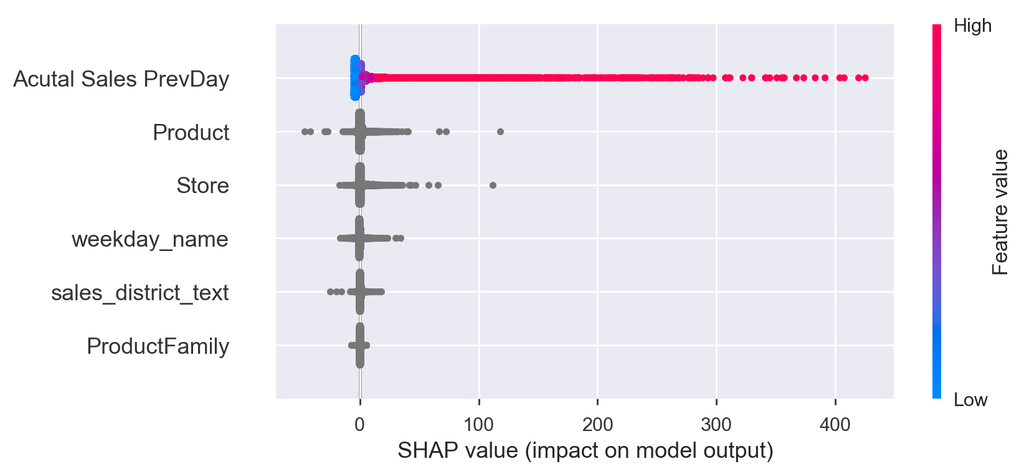

```python
import shap
from catboost import Pool
shap_values = model_appr2.get_feature_importance(Pool(X_train_appr2, y_train_appr2, cat_features=cat_features_indices), fstr_type='ShapValues')

expected_value = shap_values[0,-1]
shap_values = shap_values[:,:-1]

shap.summary_plot(shap_values, X_train_appr2)
```